# Modeling gene expression

Carlos Ramirez

June 12, 2017

#### **1. Find a model of gene expression**

Here we analyze the model of Berthomieux et al, 2013 for gene expression. In this formalism gene expression $p(t)$ dynamic is given by the next differential equation.

$$\begin{aligned}
p(t) = \frac{\partial f(t)}{\partial t} \frac{1}{a(t)}
\end{aligned}$$

Where $a(t)$ and $f(t)$ are the corrected flourescence and absorbance values defined as follows:

$$\begin{aligned}
a(t) = a_{u}(t) - a_{b}(t) \\
f(t) = f_{u}(t) - \beta(a(t))
\end{aligned}$$

In the first expression $a_{u}(t)$ and $a_{b}(t)$ are raw measured and background absorbance, respectively. Background absorbance is measured in a bacteria strain carrying an empty plasmid vector.

Finally, the $\beta$ function is an empirical interpolation curve of the map $f_{u}(t) = \beta(a_{u}(t))$ of uncorrected background values. The empirical curve is given by fitting a spline.

#### **2. Find data to model**

**2.1. Reading data for modeling**

The next plot shows the required absorbance and flourescence raw data from that reported by Berthomieux et al, 2013.

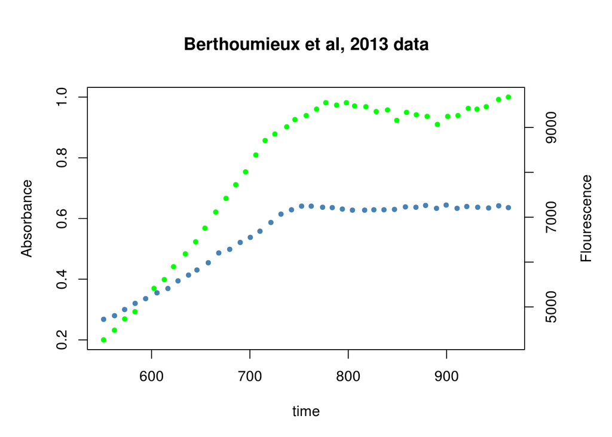

**3. Make a preliminar bioreactor like analysis**

As stated above corrected absorbance $a(t)$ is obtained by sustracting absorbance background $a_b(t)$ values from a bacteria carryng an empty plasmid vector to the absorbance raw values $a_u(t)$.

```r
## Absorbance correction
a <- absorbance$DO - absorbance.b$DO
```

A calibration curve is obtained by plotting corrected absorbance *versus* primary??? flourescence.

```r
## spline interpolation
betaFUN <- splinefun(a,flourescence$RFU)
```

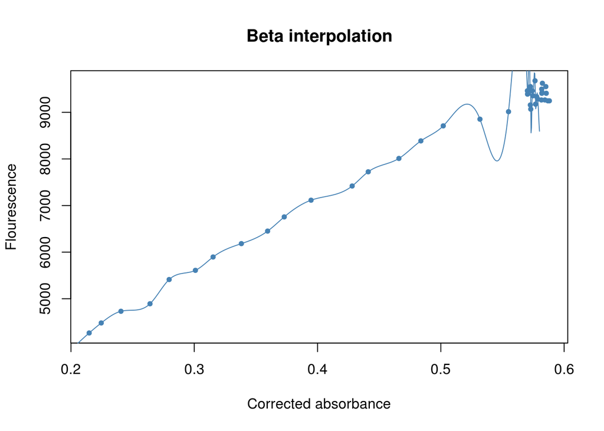

```r
f <- flourescence$RFU - betaFUN(absorbance.b$DO)
```

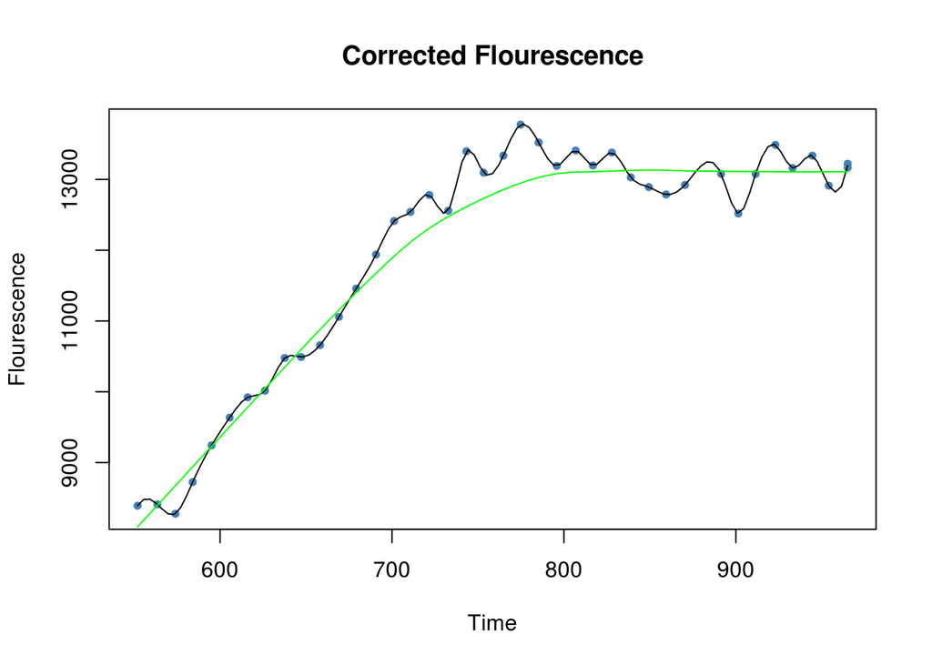

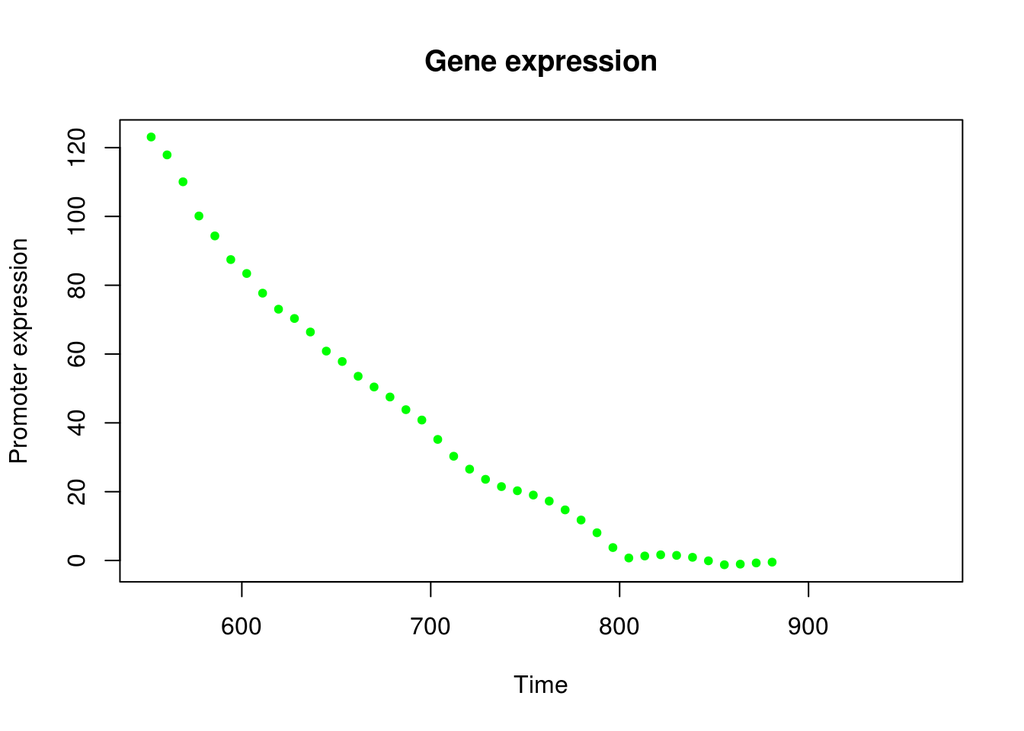

The growth rate is the function lamda which is the coefficient of the solution of the linear differential equation.